# S670 Final Project Report

STEM Graduate Students

Ankit Mathur & Nitesh Jaswal

4/28/2019

## Research question

### How does the academic experience of STEM graduate students affect their choice of staying back in the United States after graduation?

## Why should we care?

### As STEM graduate students ourselves, we believe it would be very interesting to know if our academic experience in the United States has any effect whatsoever on the likelihood of us staying back after the completion of our graduation.

## About the data

### • The dataset is a part of the International STEM Graduate Student Survey (2015) that was funded by the National Science Foundation

### • Pertains to 787 graduate students (Master’s and PhD) in STEM disciplines from 10 prestigious US universities

### Demographic variables

• Gender  
• Degree  
• Discipline  
• Home country

```
##     gender         degree                discipline   country
##  Female:292   Master's:251   Computer science :134   China:235
##  Male  :482   PhD     :536   Engineering      :262   India:202
##  NA's  : 13                  Life sciences    :141   Other:350
##                              Mathematics      : 75
##                              Other            : 60
##                              Physical sciences:115
```

### Relevant survey questions

• How do you feel you are treated by your colleagues and professors in the US in comparison with those in your home country? (Scaled response on a scale from 1 to 5 with 1 being “Much worse” and 5 being “Much better”)  
• How do you feel you would be treated by your colleagues and professors in your home country if you returned? (Scaled response on a scale from 1 to 5 with 1 being “Much worse” and 5 being “Much better”)  
• How successfully do you feel you have adjusted to American educational culture? (Scaled response on a scale from 1 to 5 with 1 being “Did not adjust well” and 5 being “Adjusted well”)  
• Please select any challenges you may have encountered while adjusting (Cultural, Social, Racial, Academic, Financial, and Other challenges)*  
• Do you hope to remain in the US after graduation?

*This was a multiple choice multi-answer question. Hence, in order to come up with meaningful charts, we have categorized the responses to this question into three categories:  
• Faced no challenges  
• Faced some challenges (Strictly less than 3 challenges)  
• Faced a lot of challenges (More than or equal to 3 challenges)

## Responses to survey questions

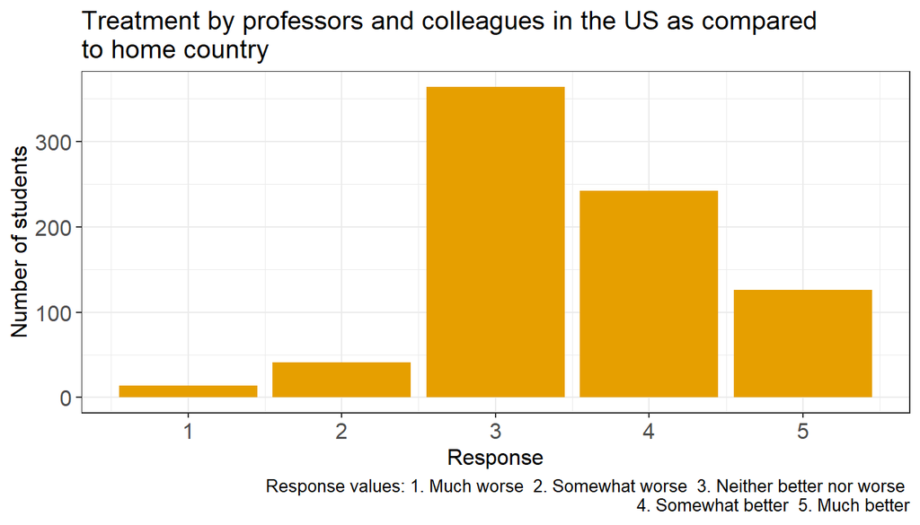

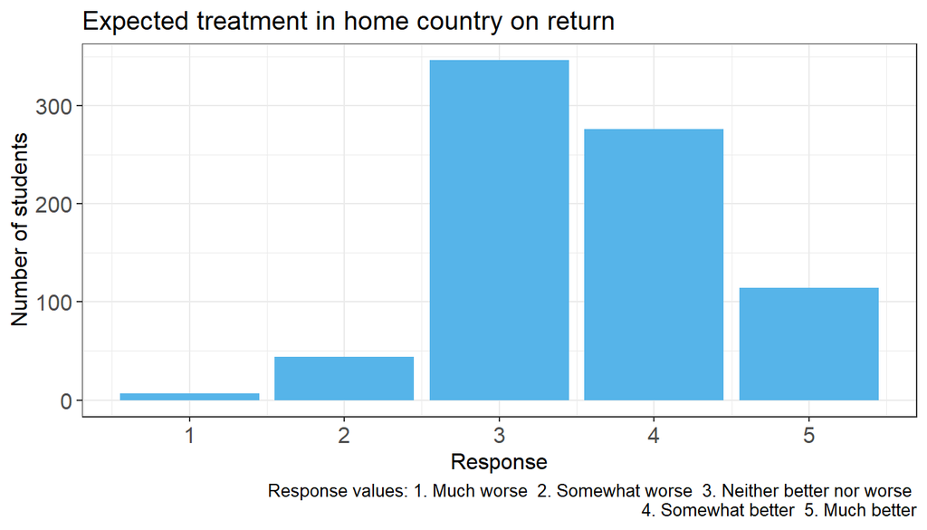

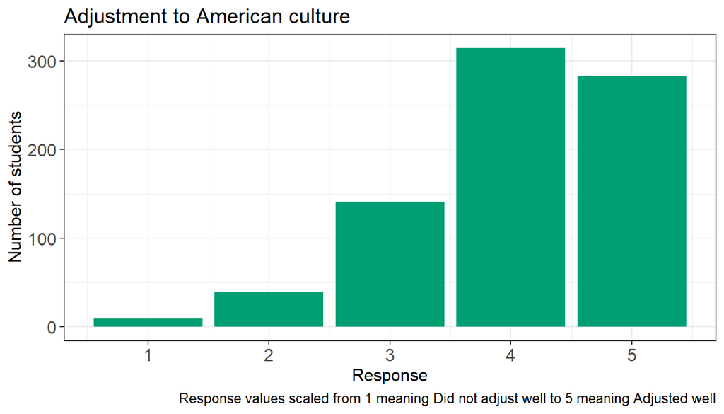

The charts corresponding to the three response variables depicted above have a lot of 4s and 5s suggesting that the academic experience of international graduate students does not seem to be bad at all. However, the chart below paints a very different picture:

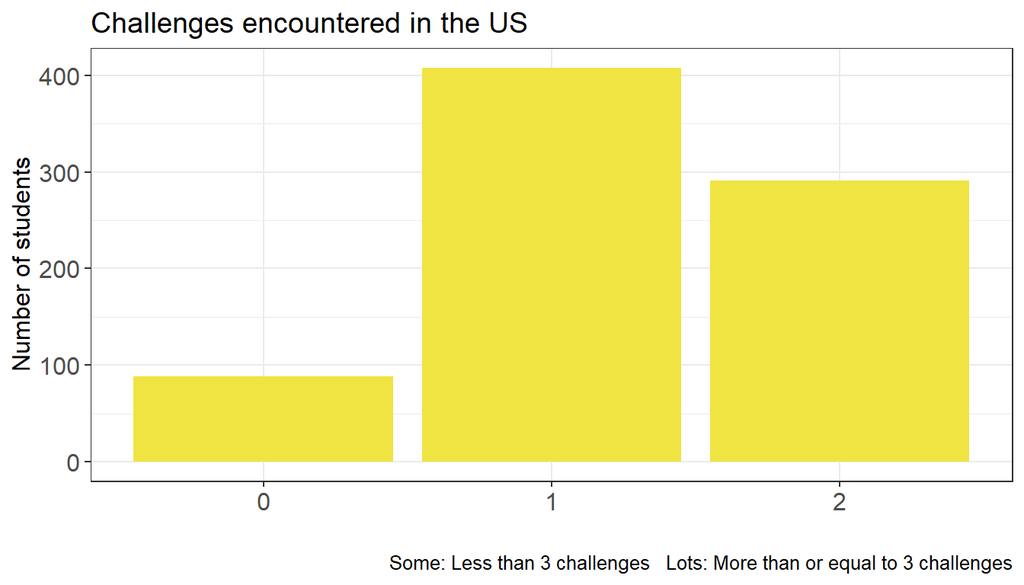

We see that fewer than 100 students faced no challenges, while more than 50% of the participating students faced one or two challenges during their stay in the United States. Approximately 300 students faced a lot of challenges.

## Bivariate plots

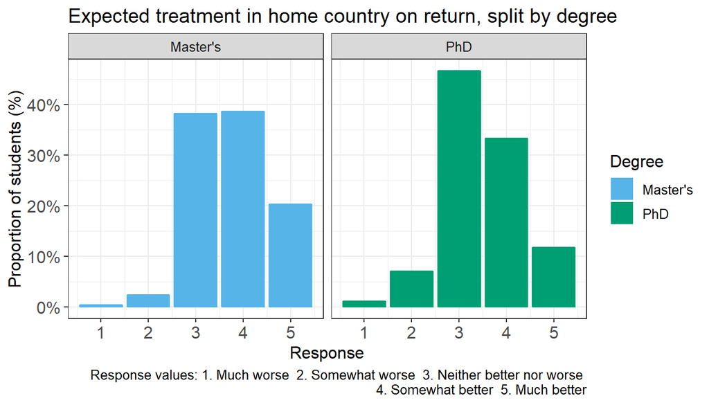

As compared to PhD students, Master’s students are more confident that they would be treated better in their home country if they were to return.

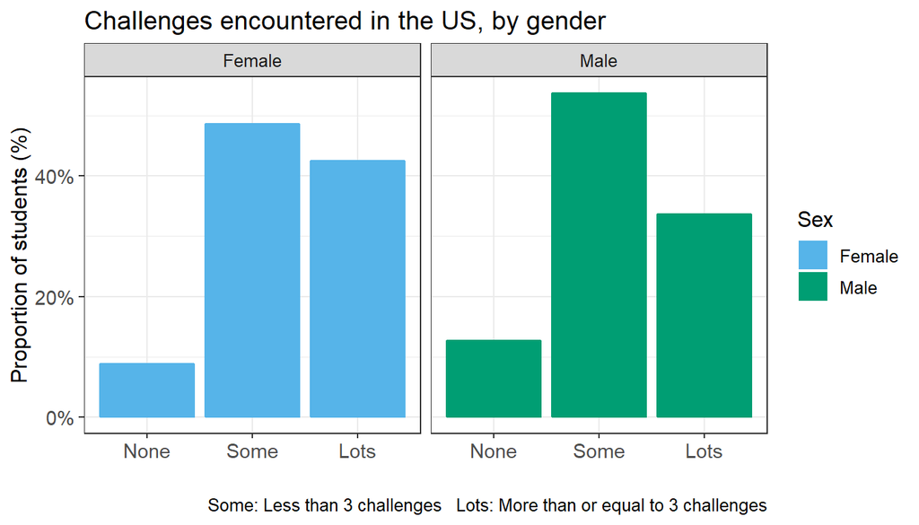

Female students face more challenges than their male counterparts.

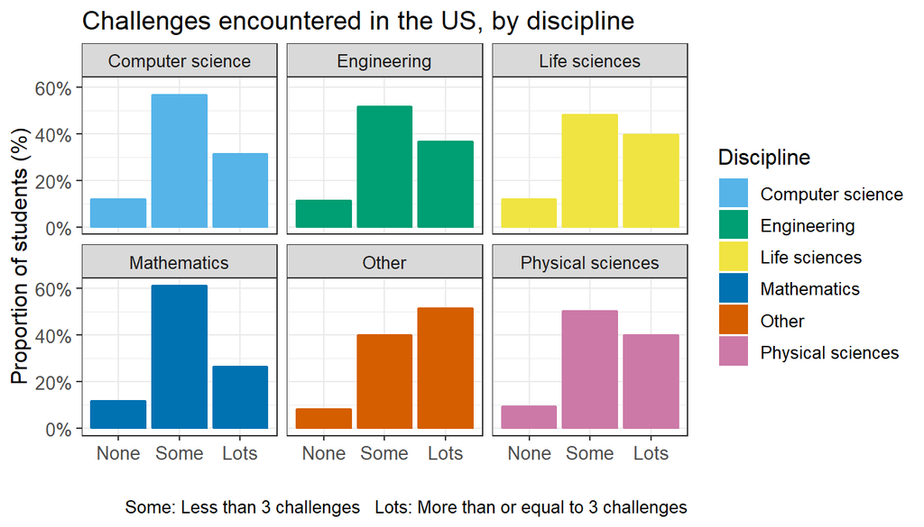

Students in other disciplines faced more challenges as compared to those in the “mainstream” subject areas.

## Behavior on the response variable

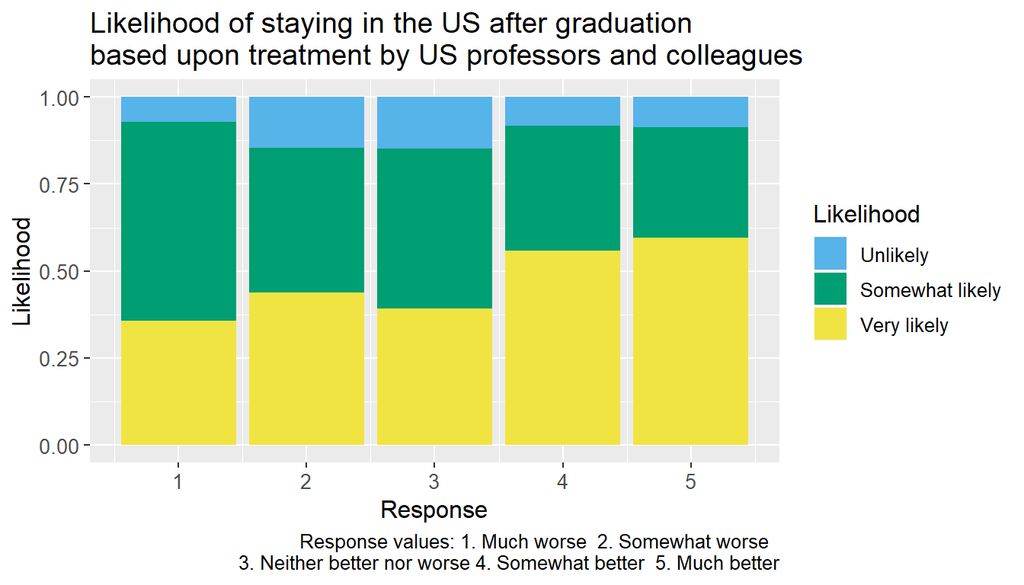

We can observe some trend in the “Very likely” cohort of responses as per which the likelihood of staying back in the US increases with better treatment by US professors and colleagues.

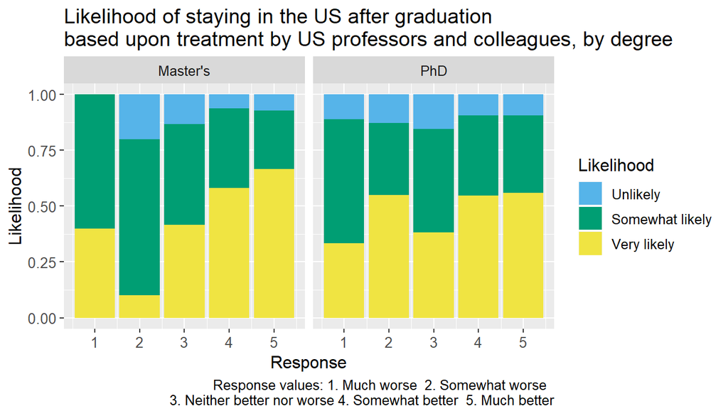

Faceting the same variable by degree, we see a clear trend in the “Very likely” cohort of responses of the Master’s students.

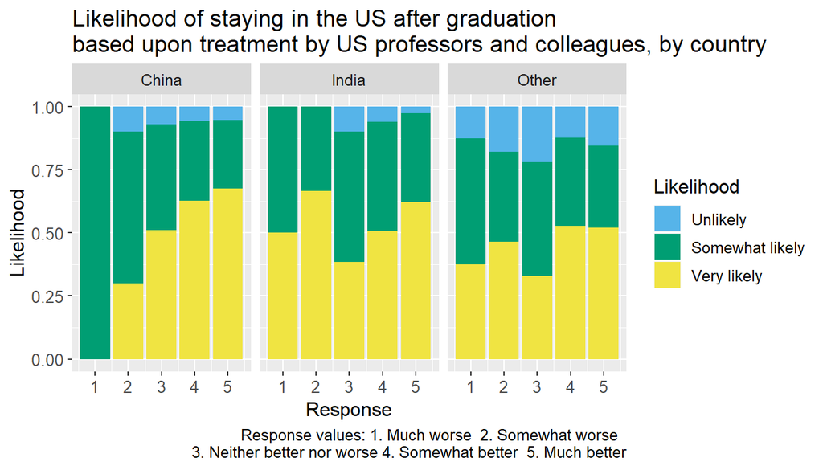

Faceting the likelihoods by home country, we see a similar trend being observed for the Chinese students suggesting an interaction.

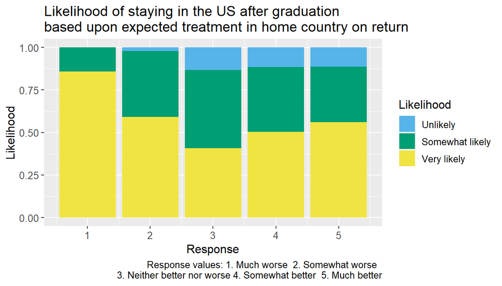

The above chart is counter-intuitive as we move from response 1 to 3, but makes sense for responses 3 to 5. This might be the case because, as we saw in the previous plots, a very small number of students responded with 1s and 2s. This suggests that we might fare better by combining the responses 1 and 2 into a single cohort.

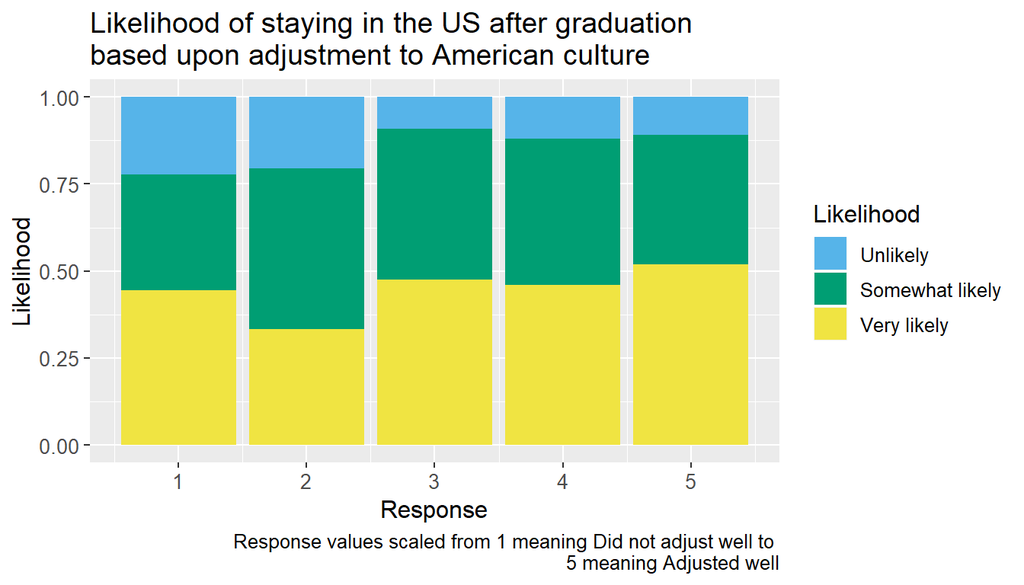

Again, we see some trend in the “Very likely” cohort with the likelihood of staying back increasing with better adjustment to American culture, which makes some intuitive sense.

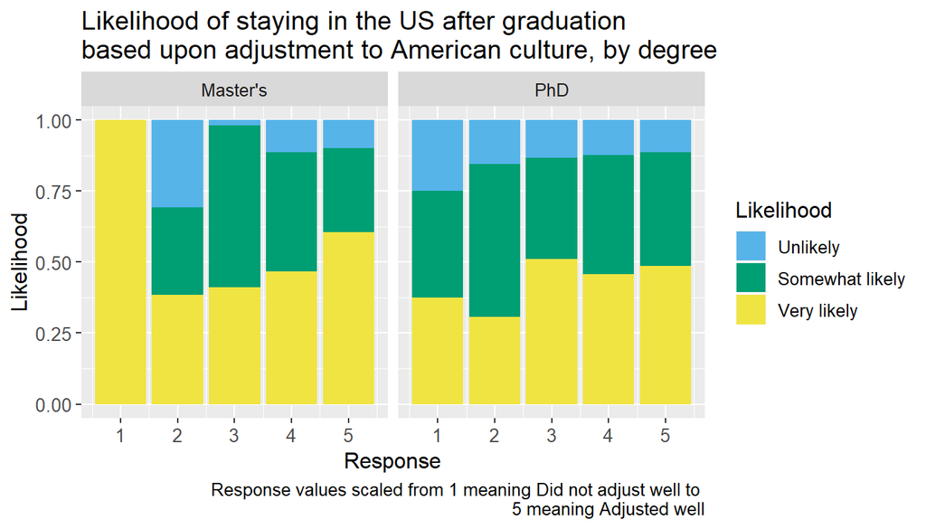

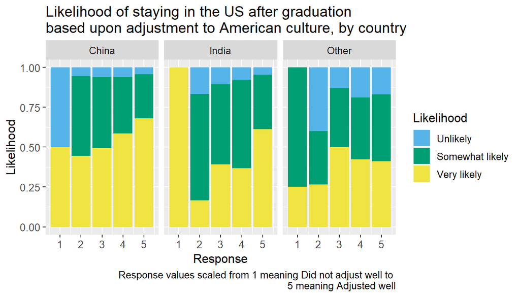

Yet again, a clear trend is observed for the Master’s and Chinese students suggesting an interaction between the predictors.

[figure not shown]

The above chart is pretty counter-intuitive across all cohorts of likelihoods as it suggests a higher likelihood of staying back in the US with higher number of challenges faced. Furthermore, since the variation across the responses is very minimal, we might fare better if we exclude this predictor while fitting the model.

## Model fitting

```
## polr(formula = likelihood ~ 1, data = inter.small)
##                             coef.est coef.se
## Unlikely|Somewhat likely    -2.02     0.11
## Somewhat likely|Very likely  0.09     0.07
## ---
## n = 787, k = 2 (including 2 intercepts)
## residual deviance = 1526.5, null deviance is not computed by polr
```

We fit a Proportional Odds Logistic Regression(POLR) model to predict the likelihood of staying back in the US. We see that the model above, which has not predictors, has a residual deviance of 1526.5, which corresponds to the null deviance in our case.  
We can now refit the POLR with the relevant predictors (after combining the 1 and 2 level responses for “Treatment in US” and “Expected treatment in home country”) and their interactions that we had observed in the previous sections.

```
##
## Re-fitting to get Hessian
```

```
## polr(formula = likelihood ~ Q40_adj + Q41_adj + Q42 + Q40_adj:degree +
##     Q40_adj:country + Q42:degree + Q42:country, data = inter.small)
##                             coef.est coef.se
## Q40_adj                      0.45     0.16
## Q41_adj                      0.09     0.09
## Q42                          0.18     0.15
## Q40_adj:degreePhD           -0.16     0.15
## Q40_adj:countryIndia        -0.19     0.18
## Q40_adj:countryOther         0.07     0.16
## Q42:degreePhD                0.13     0.13
## Q42:countryIndia             0.04     0.16
## Q42:countryOther            -0.26     0.15
## Unlikely|Somewhat likely     0.04     0.51
## Somewhat likely|Very likely  2.25     0.51
## ---
## n = 787, k = 11 (including 2 intercepts)
## residual deviance = 1478.6, null deviance is not computed by polr
```

In the summary of the model above:  
• Q40_adj is the response variable for treatment by US professors and colleagues  
• Q41_adj is the response variable for expected treatment in home country on return  
• Q42 is the response variable for adjustment to American culture

## Conclusion

As mentioned above, while the academic experience of international students does explain some variance in the likelihood of staying in the US after their graduation, it definitely is not sufficient to explain ~96% variance in our response variable. However, we do observe that the way students are treated by the US professors and colleagues during their stay, and their adjustment to the American culture do play some role in their decision-making process. We believe that including some additional relevant variables can a long way in improving our model, such as:  
• Does the student have a family business back in their home country?  
• Has the student taken an education loan for their higher studies in the US?  
• Marital status of the student  
• Is the student the only child in the family?  
• How welcoming do you find the US immigration culture?

# Appendix

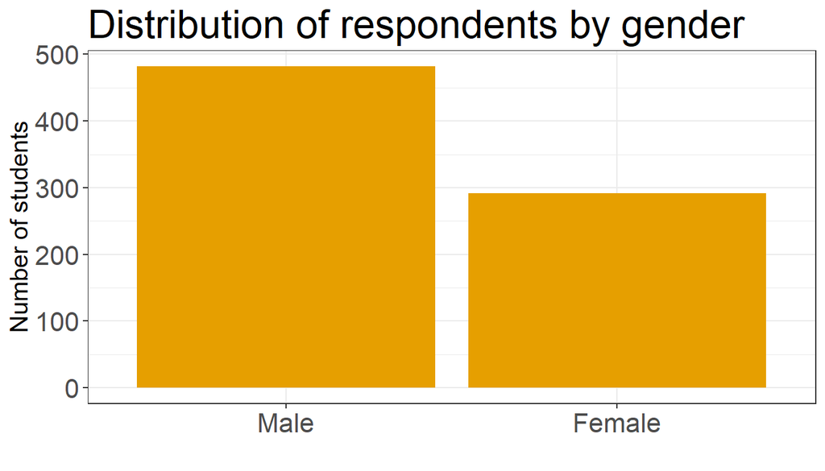

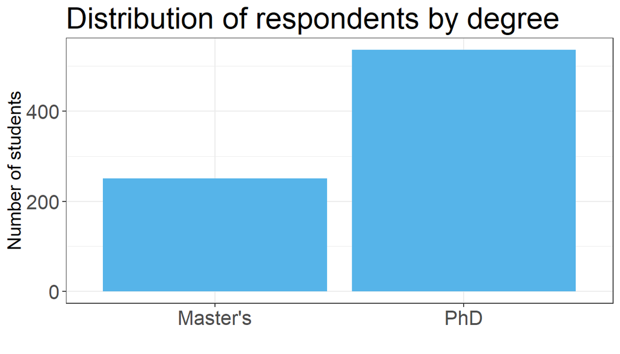

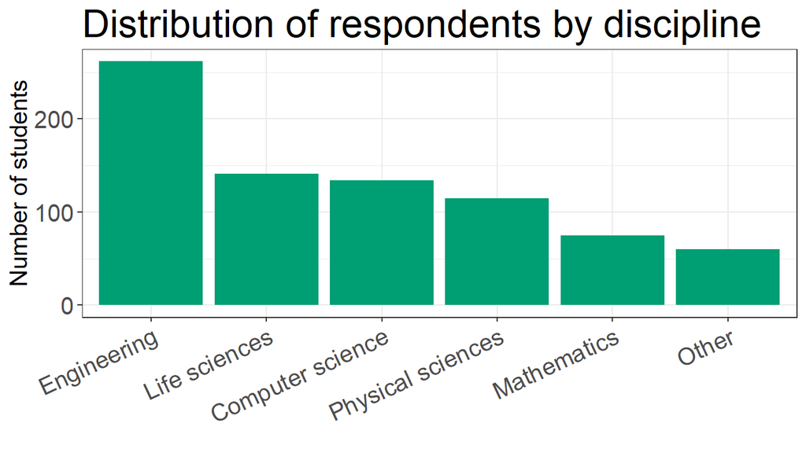

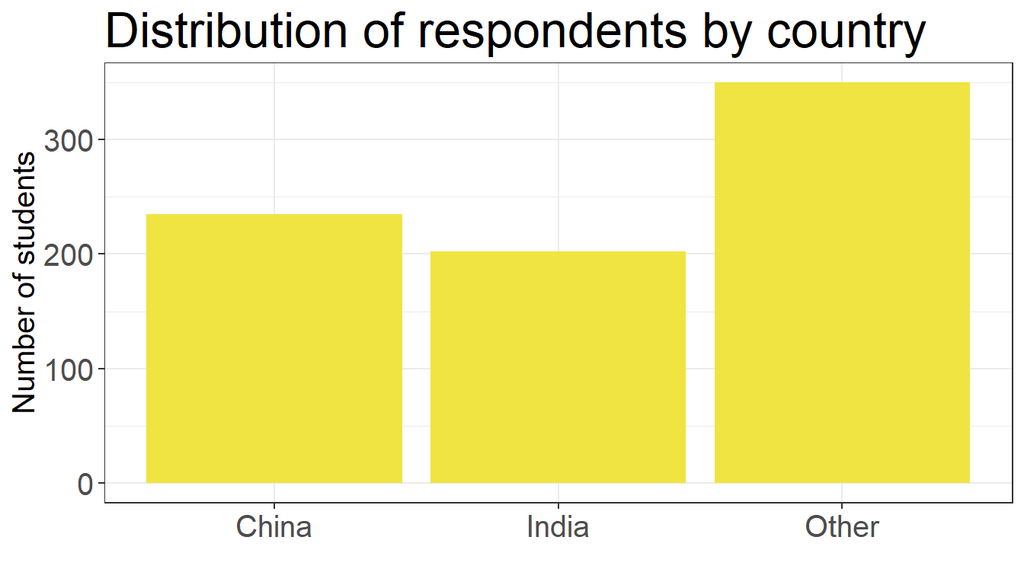

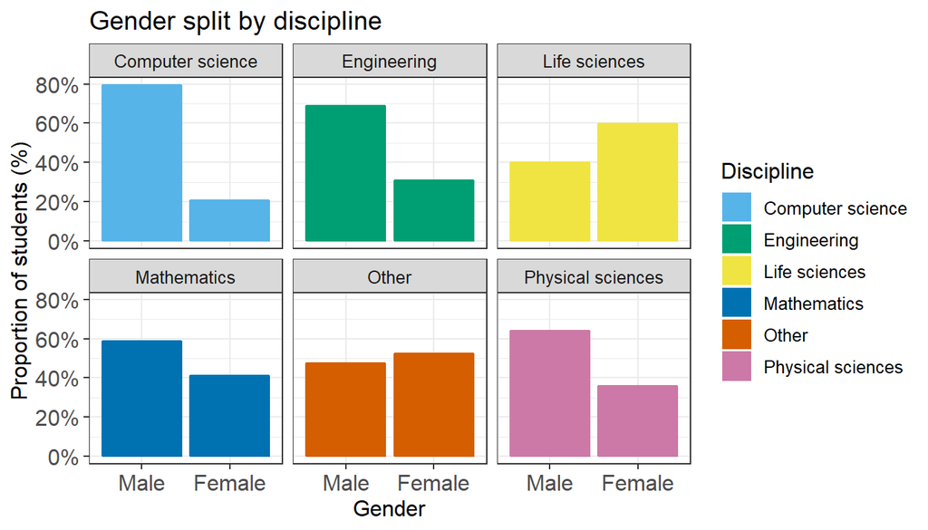

Share of females is much higher in Life sciences as compared to Computer science and Engineering disciplines where males dominate the proportion.

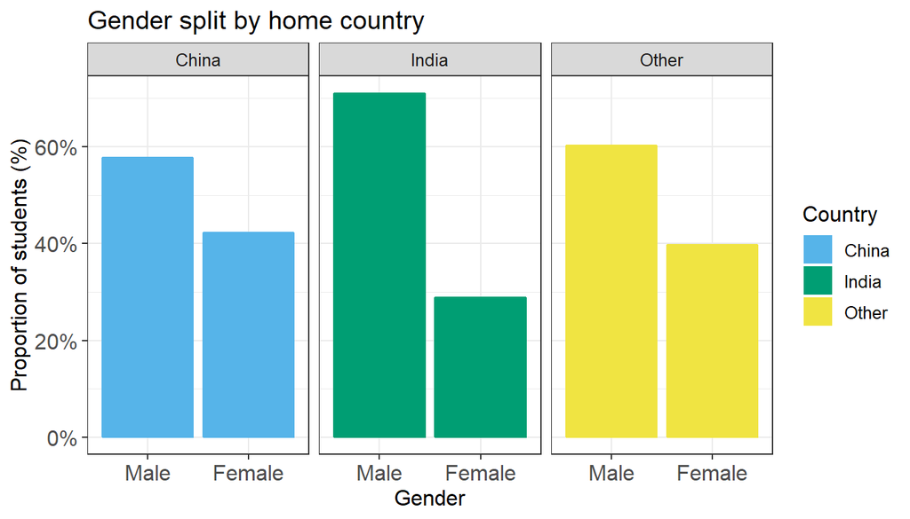

India has much higher share of male students than female students as compared to any other country.

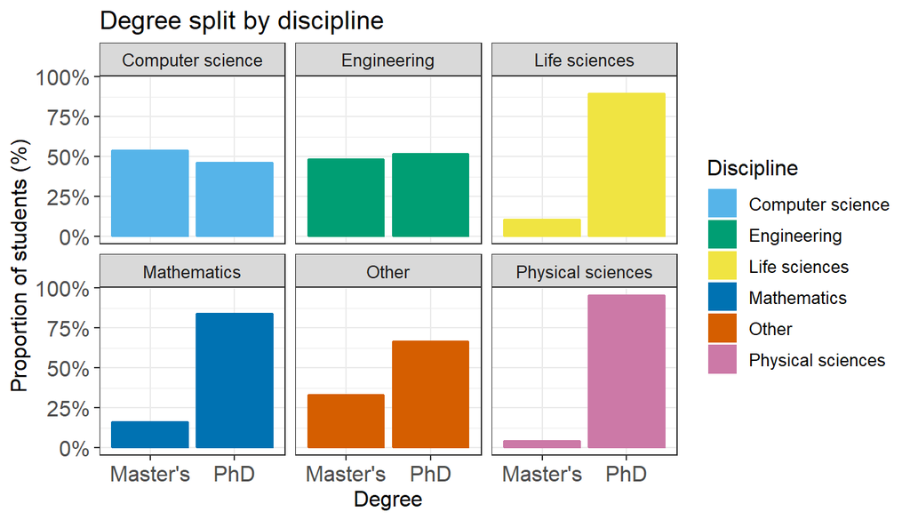

There are much more PhD students than Master’s students in Physical sciences, Life sciences and Mathematics disciplines as compared to Computer science and Engineering disciplines.

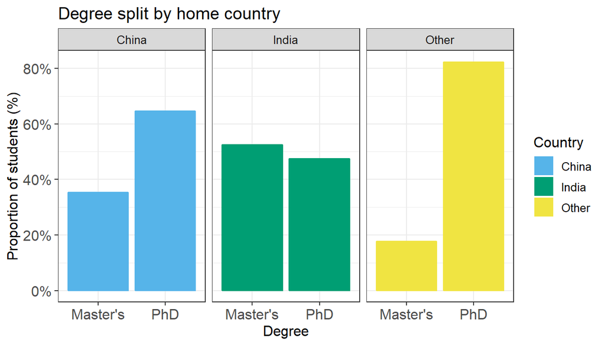

With the exception of India, the share of PhD students dominate over that of Master’s students across all countries.

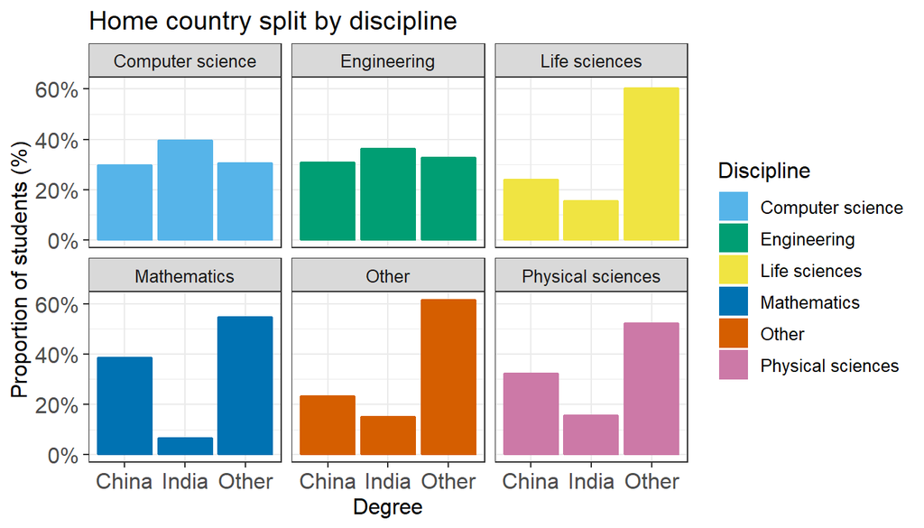

Indian students have the highest share among all countries in the Computer Science and Engineering disciplines.